# Traffic Analysis

- Show All Code
- Hide All Code

Author

Manolo Vasquez Mendoza

# Introduction

*Hello! I am Manolo Vasquez. I wanted to do a proyect to practice my data analysisa and programming skills. I chose a dataset about US Accidents found in Kaggle (https://www.kaggle.com/datasets/sobhanmoosavi/us-accidents).*

*To begin, let’s take a look to our dataset*

```python
#IMPORTING
import pandas as pd
import numpy as np
import sqlite3
from lets_plot import *
import matplotlib.pyplot as plt
LetsPlot.setup_html(isolated_frame=True)
```

```python
#lets take a look to the dataset

data_file = "data/US_Accidents_March23.csv"

use_cols = [
    'ID', 'Severity', 'Start_Time', 'State', 'City',
    'Temperature(F)', 'Visibility(mi)', 'Weather_Condition'
]
df_total = pd.read_csv(data_file, usecols=use_cols, nrows=400000)
df = df_total.sample(frac=0.75, random_state=10)
```

```python
# Agregrating useful columns
df["Start_Time"] = pd.to_datetime(df["Start_Time"])

df["Year"] = df["Start_Time"].dt.year
df["Month"] = df["Start_Time"].dt.month
df["Hour"] = df["Start_Time"].dt.hour
df['Month_Name'] = df['Start_Time'].dt.strftime('%B')

def get_season(month):
    if month in [12, 1, 2]:
        return 'Winter'
    elif month in [3, 4, 5]:
        return 'Spring'
    elif month in [6, 7, 8]:
        return 'Summer'
    else:
        return 'Fall'

df['Season'] = df['Month'].apply(get_season)

df.head()
```

|  | ID | Severity | Start_Time | City | State | Temperature(F) | Visibility(mi) | Weather_Condition | Year | Month | Hour | Month_Name | Season |
| --- | --- | --- | --- | --- | --- | --- | --- | --- | --- | --- | --- | --- | --- |
| 129534 | A-129541 | 2 | 2016-11-25 12:48:34 | Saint Petersburg | FL | 80.1 | 10.0 | Mostly Cloudy | 2016 | 11 | 12 | November | Fall |
| 325689 | A-325699 | 2 | 2017-02-06 22:06:08 | Detroit | MI | 33.1 | 6.0 | Clear | 2017 | 2 | 22 | February | Winter |
| 37156 | A-37157 | 3 | 2016-05-03 08:36:27 | Hayward | CA | 57.0 | 9.0 | Overcast | 2016 | 5 | 8 | May | Spring |
| 245048 | A-245055 | 2 | 2016-11-30 15:27:38 | Pennsauken | NJ | 60.1 | 3.0 | Overcast | 2016 | 11 | 15 | November | Fall |
| 322638 | A-322648 | 2 | 2017-01-27 19:17:46 | Bradley | SC | 43.0 | 10.0 | Clear | 2017 | 1 | 19 | January | Winter |

```python
#Cleaning NULL
df.isna().sum().sort_values(ascending=False)

df['Temperature(F)'].fillna(df['Temperature(F)'].median(), inplace=True)
df['Visibility(mi)'].fillna(df['Visibility(mi)'].median(), inplace=True)
df['Weather_Condition'].fillna("Unknown", inplace=True)
df = df.dropna(subset="City")

df.shape
```

```
(299986, 13)
```

# Question 1: WHICH ARE THE STATES WITH MORE ACCIDENTS BETWEEN 2016 AND 2017?

*Here we can see that California is clearly the state with the greatest amount of accidents between 2016 and 2017. Almost the 35.6% of the total accidents United States had happened in Califonia! This will be our state of interest for now. Here comes the questions, Why California? What happens in California that does not happen in other states? Maybe is the weather?*

```python
#Answering the question
accidents = df.query("2016 <= Year <= 2017")
accidents = accidents.groupby('State').size().reset_index(name='Total')
accidents = accidents.sort_values('Total', ascending= False)
```

```python
#Making Graphs
(
  ggplot(accidents, aes(x="Total", y="State"))+
  geom_bar(aes(x="Total",y="State", fill="Total"),stat="identity")+
  labs(
    title="States with most accidents 2016-17"
  )
)
```

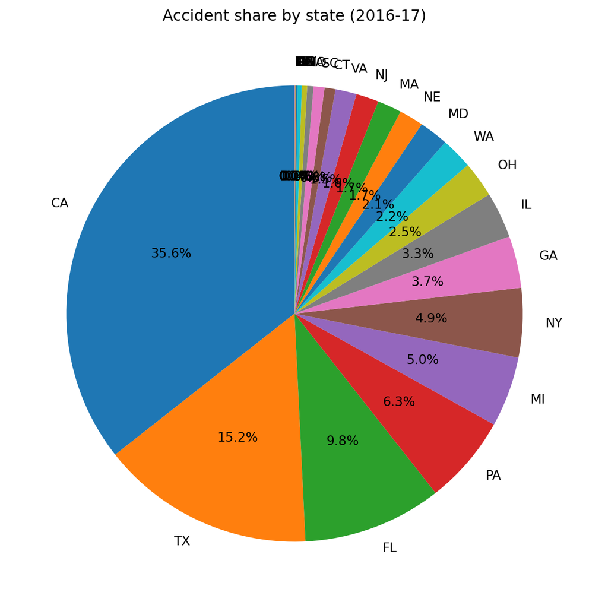

```python
#How is California in the total USA accidents
plt.figure(figsize=(8,8))
accidents_plot = accidents.set_index('State')['Total']
accidents_plot.plot.pie(autopct='%1.1f%%', startangle=90)
plt.ylabel('')
plt.title('Accident share by state (2016-17)')
plt.show()
```